# Why Julia

# Julia's Ecosystem: Basic plotting and manipulation of DataFrames

Julia's ecosystem is composed by a variety of libraries which focus on technical domains such as Data Science (DataFrames.jl, CSV.jl, JSON.jl), Machine Learning (MLJ.jl, Flux.jl, Turing.jl) and Scientific Computing (DifferentialEquations.jl), as well as more general purpose programming (HTTP.jl, Dash.jl). We will now consider one of the libraries that will be accompanying us throughout the book to make visualizations, Plots.jl.

To install the Plots.jl library we need to go to the Julia package manager mode as we saw earlier.

```julia
julia> ]
(@v1.5) pkg>
(@v1.5) pkg> add Plots.jl
```

There are some other great packages like Gadfly.jl and VegaLite.jl, but Plots will be the best to get you started. Let's import the library with the 'using' keyword and start making some plots. We will plot the first ten numbers of the fibonacci sequence using the `scatter()` function.

7.6 μs

### Plotting with Plots.jl

Let's make a plot of the 10 first numbers in the fibonacci sequence. For this, we can make use of the `scatter()` function:

4.5 μs

[figure not shown]

```
xxxxxxxxxx
```

7

1

```
begin
```

2

```
    using Plots
```

3

4

```
    sequence = [0, 1, 1, 2, 3, 5, 8, 13, 21, 34]
```

5

6

```
    scatter(sequence, xlabel="n", ylabel="Fibonacci(n)", color="purple", label=false, size=(450, 300))
```

7

```
end
```

13.4 s

The only really important argument of the scatter function in the example above is *sequence*, the first one, which tells the function what is the data we want to plot. The other arguments are just details to make the visualization prettier. Here we have used the scatter function because we want a discrete plot for our sequence. In case we wanted a continuous one, we could have used `plot()`. Let's see this applied to our fibonacci sequence:

9.3 μs

[figure not shown]

```
xxxxxxxxxx
```

1

1

```
plot(sequence, xlabel="x", ylabel="Fibonacci", linewidth=3, label=false, color="green", size=(450, 300))
```

15.8 s

[figure not shown]

```
xxxxxxxxxx
```

4

1

```
begin
```

2

```
    plot(sequence, xlabel="x", ylabel="Fibonacci", linewidth=3, label=false, color="green", size=(450, 300))
```

3

```
    scatter!(sequence, label=false, color="purple", size=(450, 300))
```

4

```
end
```

1.9 s

In the example above, a plot is created when we call the `plot()` function. What the `scatter!()` call then does, is to modify the global state of the plot in-place. If not done this way, both plots wouldn't be sketched together.

A nice feature that the Plots.jl package offers, is the fact of changing plotting backends. There exist various plotting packages in Julia, and each one has its own special features and aesthetic flavour. The Plots.jl package integrates these plotting libraries and acts as an interface to communicate with them in an easy way. By default, the `GR` backend is the one used. In fact, this was the plotting engine that generated the plots we have already done. The most used and maintained plotting backends up to date, are the already mentioned `GR`, `Plotly/PlotlyJS`, `PyPlot`, `UnicodePlots` and `InspectDR`. The backend you choose will depend on the particular situation you are facing. For a detailed explanation on backends, we recommend you visit the Julia Plots [documentation](https://docs.juliaplots.org/latest/backends/). Through the book we will be focusing on the `GR`backend, but as a demonstration of the ease of changing from one backend to another, consider the code below. The only thing added to the code for plotting that we have already used, is the `pyplot()` call to change the backend. If you have already coded in Python, you will feel familiar with this plotting backend.

8.3 μs

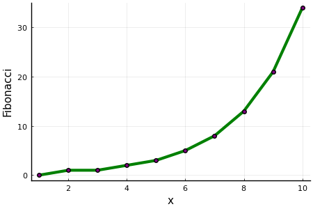

```
xxxxxxxxxx
```

5

1

```
begin
```

2

```
    pyplot()
```

3

```
    plot(sequence, xlabel="x", ylabel="Fibonacci", linewidth=3, label=false, color="green", size=(450, 300))
```

4

```
    scatter!(sequence, label=false, color="purple", size=(450, 300))
```

5

```
end
```

10.1 s

Analogously, we can use the `plotlyjs` backend, which is specially suited for interactivity.

4.1 μs

[interactive chart not shown]

```
xxxxxxxxxx
```

5

1

```
begin
```

2

```
    plotlyjs()
```

3

```
    plot(sequence, xlabel="x", ylabel="Fibonacci", linewidth=3, label=false, color="green", size=(450, 300))
```

4

```
    scatter!(sequence, label=false, color="purple", size=(450, 300))
```

5

```
end
```

16.3 s

Each of these backends has its own scope, so there may be plots that one backend can do that other can't. For example, 3D plots are not supported for all backends. The details are well explained in the Julia documentation.

2.6 μs

### Introducing DataFrames.jl

When dealing with any type of data in large quantities, it is essential to have a framework to organize and manipulate it in an efficient way. If you have previously used Python, you probably came across the Pandas package and dataframes. In Julia, the DataFrames.jl package follows the same idea. Dataframes are objects with the purpose of structuring tabular data in a smart way. You can think of them as a table, a matrix or a spreadsheet. In the dataframe convention, each row is an observation of a vector-type variable, and each column is the complete set of values of a given variable, across all observations. In other words, for a single row, each column represents a a realization of a variable. Let's see how to construct and load data into a dataframe. There are many ways you can accomplish this. Consider we had some data in a matrix and we want to organize it in a dataframe. First, we are going to create some 'fake data' and loading that in a Julia DataFrame,

3.7 μs

x1

x2

x3

x4

x5

Float64

Float64

Float64

Float64

Float64

1

```
0.768448
```

```
0.662555
```

```
0.163666
```

```
0.463847
```

```
0.70586
```

2

```
0.940515
```

```
0.586022
```

```
0.473017
```

```
0.275819
```

```
0.291978
```

3

```
0.673959
```

```
0.0521332
```

```
0.865412
```

```
0.446568
```

```
0.281066
```

4

```
0.395453
```

```
0.26864
```

```
0.617492
```

```
0.582318
```

```
0.792931
```

5

```
0.313244
```

```
0.108871
```

```
0.285698
```

```
0.255981
```

```
0.20923
```

```
xxxxxxxxxx
```

10

1

```
begin
```

2

```
    using DataFrames, Random
```

3

4

```
    Random.seed!(123)
```

5

6

```
    fake_data = rand(5, 5) # this creates a 5x5 matrix with random values between 0
```

7

```
                           # and 1 in each matrix element.
```

8

9

```
    df = DataFrame(fake_data)
```

10

```
end
```

3.0 s

3.0 μs

one

two

three

four

five

Float64

Float64

Float64

Float64

Float64

1

```
0.768448
```

```
0.662555
```

```
0.163666
```

```
0.463847
```

```
0.70586
```

2

```
0.940515
```

```
0.586022
```

```
0.473017
```

```
0.275819
```

```
0.291978
```

3

```
0.673959
```

```
0.0521332
```

```
0.865412
```

```
0.446568
```

```
0.281066
```

4

```
0.395453
```

```
0.26864
```

```
0.617492
```

```
0.582318
```

```
0.792931
```

5

```
0.313244
```

```
0.108871
```

```
0.285698
```

```
0.255981
```

```
0.20923
```

```
xxxxxxxxxx
```

1

1

```
rename!(df, ["one", "two", "three", "four", "five"])
```

23.2 μs

The first argument of the function is the dataframe we want to modify, and the second an array of strings, each one corresponding to the name of each column. Another way to create a dataframe is by passing a list of variables that store arrays or any collection of data. For example,

2.8 μs

column1

column2

column3

Int64

Int64

Int64

1

```
1
```

```
2
```

```
3
```

2

```
2
```

```
4
```

```
6
```

3

```
3
```

```
6
```

```
9
```

4

```
4
```

```
8
```

```
12
```

5

```
5
```

```
10
```

```
15
```

6

```
6
```

```
12
```

```
18
```

7

```
7
```

```
14
```

```
21
```

8

```
8
```

```
16
```

```
24
```

9

```
9
```

```
18
```

```
27
```

10

```
10
```

```
20
```

```
30
```

```
xxxxxxxxxx
```

1

1

```
DataFrame(column1=1:10, column2=2:2:20, column3=3:3:30)
```

55.7 ms

As you can see, the name of each array is automatically assigned to the columns of the dataframe. Furthermore, you can initialize an empty dataframe and start adding data later if you want,

2.9 μs

Names

Countries

Ages

String

String

Int64

1

```
"Juan"
```

```
"Argentina"
```

```
28
```

```
xxxxxxxxxx
```

6

1

```
begin
```

2

```
    df_ = DataFrame(Names = String[],
```

3

```
                Countries = String[],
```

4

```
                Ages = Int64[])
```

5

```
    df_ = vcat(df_, DataFrame(Names="Juan", Countries="Argentina", Ages=28))
```

6

```
end
```

1.0 s

We have used the `vcat()`function seen earlier to append new data to the dataframe.

You can also add a new column very easily,

4.1 μs

Names

Countries

Ages

height

String

String

Int64

Float64

1

```
"Juan"
```

```
"Argentina"
```

```
28
```

```
1.72
```

```
xxxxxxxxxx
```

4

1

```
begin
```

2

```
    df_.height = [1.72]
```

3

```
    df_
```

4

```
end
```

5.9 μs

You can access data in a dataframe in various ways. One way is by the column name. For example,

3.7 μs

Float641

```
0.163666
```

2

```
0.473017
```

3

```
0.865412
```

4

```
0.617492
```

5

```
0.285698
```

```
xxxxxxxxxx
```

1

1

```
df.three
```

1.0 μs

Float641

```
0.163666
```

2

```
0.473017
```

3

```
0.865412
```

4

```
0.617492
```

5

```
0.285698
```

```
xxxxxxxxxx
```

1

1

```
df."three"
```

3.2 μs

But you can also access dataframe data as if it were a matrix. You can treat columns either as their column number or by their name,

4.0 μs

DataFrameRow (5 columns)

|  | one Float64 | two Float64 | three Float64 | four Float64 | five Float64 |
| --- | --- | --- | --- | --- | --- |
| 1 | 0.768448 | 0.662555 | 0.163666 | 0.463847 | 0.70586 |

```
xxxxxxxxxx
```

1

1

```
df[1,:]
```

1.9 μs

Float641

```
0.768448
```

2

```
0.940515
```

```
xxxxxxxxxx
```

1

1

```
df[1:2, "one"]
```

7.4 μs

two

four

five

Float64

Float64

Float64

1

```
0.0521332
```

```
0.446568
```

```
0.281066
```

2

```
0.26864
```

```
0.582318
```

```
0.792931
```

3

```
0.108871
```

```
0.255981
```

```
0.20923
```

```
xxxxxxxxxx
```

1

1

```
df[3:5, ["two", "four", "five"]]
```

32.0 μs

The column names can be accessed by the `names()` function,

3.1 μs

String1

```
"one"
```

2

```
"two"
```

3

```
"three"
```

4

```
"four"
```

5

```
"five"
```

```
xxxxxxxxxx
```

1

1

```
names(df)
```

4.6 μs

Another useful tool for having a quick overview of the dataframe, typically when in an exploratory process, is the `describe()` function. It outputs some information about each column, as you can see below,

3.4 μs

variable

mean

min

median

max

nmissing

eltype

Symbol

Float64

Float64

Float64

Float64

Int64

DataType

1

```
:one
```

```
0.618324
```

```
0.313244
```

```
0.673959
```

```
0.940515
```

```
0
```

```
Float64
```

2

```
:two
```

```
0.335644
```

```
0.0521332
```

```
0.26864
```

```
0.662555
```

```
0
```

```
Float64
```

3

```
:three
```

```
0.481057
```

```
0.163666
```

```
0.473017
```

```
0.865412
```

```
0
```

```
Float64
```

4

```
:four
```

```
0.404907
```

```
0.255981
```

```
0.446568
```

```
0.582318
```

```
0
```

```
Float64
```

5

```
:five
```

```
0.456213
```

```
0.20923
```

```
0.291978
```

```
0.792931
```

```
0
```

```
Float64
```

```
xxxxxxxxxx
```

1

1

```
describe(df)
```

860 ms

3.1 μs

one

two

three

four

five

Float64

Float64

Float64

Float64

Float64

1

```
0.395453
```

```
0.26864
```

```
0.617492
```

```
0.582318
```

```
0.792931
```

2

```
0.313244
```

```
0.108871
```

```
0.285698
```

```
0.255981
```

```
0.20923
```

```
xxxxxxxxxx
```

1

1

```
filter(col -> col[1] < 0.5, df)
```

155 ms

A very usual application of dataframes is when dealing with CSV data. In case you are new to the term, CSV stands for Comma Separated Values. As the name indicates, these are files where each line is a data record, composed by values separated by commas. In essence, a way to store tabular data. A lot of the datasets around the internet are available in this format, and naturally, the DataFrame.jl package is well integrated with it. As an example, consider the popular Iris flower dataset. This dataset consists of samples of three different species of plants. The samples correspond to four measured features of the flowers: length and width of the sepals and petals. To work with CSV files, the package CSV.jl is your best choice in Julia. Loading a CSV file is very easy once you have it downloaded. Consider the following code,

2.9 μs

Id

SepalLengthCm

SepalWidthCm

PetalLengthCm

PetalWidthCm

Species

Int64

Float64

Float64

Float64

Float64

String

1

```
1
```

```
5.1
```

```
3.5
```

```
1.4
```

```
0.2
```

```
"Iris-setosa"
```

2

```
2
```

```
4.9
```

```
3.0
```

```
1.4
```

```
0.2
```

```
"Iris-setosa"
```

3

```
3
```

```
4.7
```

```
3.2
```

```
1.3
```

```
0.2
```

```
"Iris-setosa"
```

4

```
4
```

```
4.6
```

```
3.1
```

```
1.5
```

```
0.2
```

```
"Iris-setosa"
```

5

```
5
```

```
5.0
```

```
3.6
```

```
1.4
```

```
0.2
```

```
"Iris-setosa"
```

6

```
6
```

```
5.4
```

```
3.9
```

```
1.7
```

```
0.4
```

```
"Iris-setosa"
```

7

```
7
```

```
4.6
```

```
3.4
```

```
1.4
```

```
0.3
```

```
"Iris-setosa"
```

8

```
8
```

```
5.0
```

```
3.4
```

```
1.5
```

```
0.2
```

```
"Iris-setosa"
```

9

```
9
```

```
4.4
```

```
2.9
```

```
1.4
```

```
0.2
```

```
"Iris-setosa"
```

10

```
10
```

```
4.9
```

```
3.1
```

```
1.5
```

```
0.1
```

```
"Iris-setosa"
```

more

150

```
150
```

```
5.9
```

```
3.0
```

```
5.1
```

```
1.8
```

```
"Iris-virginica"
```

```
xxxxxxxxxx
```

5

1

```
begin
```

2

```
    using CSV
```

3

4

```
    iris_df = CSV.File("./data/Iris.csv") |> DataFrame
```

5

```
end
```

9.8 s

Here we used the pipeline operator `|>`, which is mainly some Julia syntactic sugar. It resembles the flow of information. First, the `CSV.File()`function, loads the CSV file and creates a CSV File object, that is passed to the `DataFrame()`function, to give us finally a dataframe. Once you have worked on the dataframe cleaning data or modifying it, you can write a CSV text file from it and in this way, you can share your work with other people. For example, consider I want to filter one of the species of plants, 'Iris-setosa', and then I want to write a file with this modified data to share it with someone,

3.2 μs

```
xxxxxxxxxx
```

4

1

```
begin
```

2

```
    filter!(row -> row.Species != "Iris-setosa", iris_df)
```

3

```
    CSV.write("./data/modified_iris.csv", iris_df)
```

4

```
end;
```

856 ms

Plotting Dataframes data is very easy. Suppose we want to plot the flower features from the iris dataset, all in one single plot. These features correspond to the columns two to five of the dataframe. Thinking about it as a matrix, you can access these data by selecting all the rows for each of the corresponding columns. In the code below, a loop is performed over the columns of interest. The `plot()` statement, with no arguments, is a way to create an empty instance of a plot, like a blank canvas. This empty plot will be successively overwritten by each call to `plot!()`. Finally, we make a call to `current()`, to display the plot. You may be wondering why this is necessary. Notice that all the plotting happens inside a loop, hence the plotting iterations are not displayed. It is more efficient to display the finished plot when the loop is over than to update each plot as it overwrites the previous one.

3.1 μs

[figure not shown]

```
xxxxxxxxxx
```

12

1

```
begin
```

2

```
    gr()
```

3

```
    plot()
```

4

```
    for i in 2:5
```

5

```
        plot!(iris_df[:,i], legend=false)
```

6

```
    end
```

7

```
    xlabel!("Flower")
```

8

```
    ylabel!("Centimeters (cm)")
```

9

```
    title!("Flower features")
```

10

```
    current()
```

11

```
end
```

12

3.7 s

### Summary

In this chapter we have introduced the Julia language, the motivations behind its creation, features, installation and basic building blocks for writing some code. First we discussed some basic Julia operators and datatypes. Some special features of the language such as how to write different kinds of arrays and broadcasting were detailed. We then followed with an overview of how functions work in Julia, and how to make your own. Finally, we introduced some packages of the Julia ecosystem, mainly the Plots.jl package for plotting and changing backends, and DataFrames.jl for data organization and manipulation.

4.1 μs

### References

- [Julia's website](https://julialang.org/)
- [Julia REPL](https://docs.julialang.org/en/v1/stdlib/REPL/)
- [Learn X in Y minutes](https://learnxinyminutes.com/docs/julia/)
- [Introducing Julia](https://en.wikibooks.org/wiki/Introducing_Julia)
- [Julia Plots - Backends](https://docs.juliaplots.org/latest/backends/)
- [Data Science with Julia](https://www.amazon.com/Data-Science-Julia-Paul-McNicholas/dp/1138499986)
- [Comma Separated Values](https://en.wikipedia.org/wiki/Comma-separated_values)
- [Iris Dataset](https://en.wikipedia.org/wiki/Iris_flower_data_set)

13.4 μs

### Give us feedback

This book is currently in a beta version. We are looking forward to getting feedback and criticism:

- Submit a GitHub issue **[here](https://github.com/unbalancedparentheses/data_science_in_julia_for_hackers/issues)**.
- Mail us to **martina.cantaro@lambdaclass.com**

Thank you!

17.0 μs

[Next chapter](https://datasciencejuliahackers.com/03_probability_intro.jl.html)

6.6 μs